# PROBLEM SET 2

Jacob Jameson

Due on Tuesday March 7, 2023

### IDENTIFICATION

1. Your information

Jacob Jameson

2. Group Members (please list below the classmates you worked with on this problem set):

Bohan Li, Jenna Rogers

3. Compliance with Harvard Kennedy School Academic Code

I certify that my work in this problem set complies with the Harvard Kennedy School Academic Code

### Conceptual Questions

1. Read the paper. In a couple of sentences, explain the primary research question that the authors are trying to answer. What is the key logic behind the authors’ answer? In a separate sentence, explain why policymakers should care about that question. Use non-technical jargon so that someone without statistical training could understand.

2. The authors used an instrumental variable approach because they believed a naïve observational regression specification (regressing earnings on education) would be insufficient. What are two possible confounders (omitted variables) that would bias the results from this regression? Explain the mechanism of the omitted variable and use the omitted variable bias formula to argue whether it would lead to an understatement or overstatement of the true effect.

The omitted variable bias formula is given by $\alpha_1 = \beta_1 + \beta_2\gamma_1$, where $\alpha_1$ is the coefficient from the regression, $\beta_1$ is the true coefficient, $\beta_2$ is the coefficient of the omitted variable in the true regression, and $\gamma_1$ is the coefficient on the variable of interest in an auxiliary regression of the omitted variable on the variable of interest.

Two possible confounders that would bias the results from the naïve regression are natural ability and socioeconomic status. Natural ability is positively associated with earnings ($\beta_2>0$) and education ($\gamma_1>0$), leading to an overestimate of the true effect. Similarly, socioeconomic status is also positively associated with earnings ($\beta_2>0$) and education ($\gamma_1>0$), resulting in an overestimate of the true effect if omitted.

3. What is/are the instrument(s) used by the authors in this study, and what are those instruments instrumenting for?

The instrument used in the study is quarter of birth, which is considered to be exogenous and affects the level of compulsory schooling. More specifically, quarter of birth is used to instrument for the number of years of education completed due to the effect it has on the age at which individuals enter school and the subsequent length of time they are required to attend.

4. Generally, what characteristics must an instrument have for it to be considered valid?
1. Explain these characteristics in words, and specific terms of the instrument(s) used in the paper.

For an instrument to be considered valid, it must have four characteristics:

Relevance: The instrument must affect the treatment status, which in this paper means that quarter of birth must affect years of education.

Independence: The instrument must be as good as randomly assigned, which in this paper means that quarter of birth must be as good as random.

Exclusion: The instrument must affect the outcome only through the treatment, which in this paper means that quarter of birth can only affect log earnings via years of education.

Monotonicity: The instrument must affect everyone in the same way, which in this paper means that being born in an early quarter weakly decreases the number of years of compulsory education, and no one actually gets more years of education when they are born in an early quarter.

2. Explain these characteristics using random variables and potential outcomes.

To explain the characteristics of a valid instrument using random variables and potential outcomes, we can define the following variables:

$D_i$ as the indicator for treatment status

$Z_i$ as the indicator for the instrument

$Y_i$ as the outcome variable

The characteristics are:

Relevance: $E[D_i(1)-D_i(0)]\neq 0$, meaning that the instrument must affect the treatment status.

Independence: $[\{Y(D_i,Z_i);\forall D,Z\},D_i(1),D_i(0)]\perp Z_i$, meaning that the instrument must be independent of the potential outcomes given the treatment status.

Exclusion: $Y_i(D_i,Z_i)$ is only a function of $D_i$, which means that the instrument must affect the outcome only through the treatment status.

Monotonicity: $D_i(1)\geq D_i(0)$ for all $i$, or the reverse. This means that the instrument must have a monotonic effect on the treatment status.

5. Do you believe that the instrument(s) in the paper is/are truly exogenous? Why or why not? If so, provide a brief argument for this assumption. If not, provide an alternate mechanism for how the exogeneity assumption may be violated.

I believe that the instrument used in the paper is exogenous. The authors provide several reasons and robustness checks to support this assumption, including the unlikelihood of parents timing the birth of their children, the absence of systematic differences in the characteristics of individuals born in different quarters, and tests for differential trends and sensitivity to alternative specifications. While there may be unobserved factors that could affect the timing of birth, the authors’ argument and evidence provide strong support for the exogeneity assumption.

6. To assess whether the instrument is relevant, we can examine whether the instrument (quarter of birth) predicts the instrumentalized variable (compulsory schooling). In the following parts a - c, provide interpretations with concrete units, in a way a policymaker can understand.
1. Explain how Table 1 is constructed, and give some intuition for the authors’ choices.

Table 1 presents estimates of the effect of each quarter of birth on the outcome variables, relative to individuals born in the 4th quarter. To construct this table, the authors regress the de-trended outcome variables, such as total years of education or high school graduation, on a set of indicator variables indicating the quarter of birth. The table also includes an F-test p-value, which tests whether there are significant within-year-of-birth differences in the average years of education.

2. Interpret the coefficient of the first quarter for the outcome variables “Total years of education” and “High school graduate” of the 1930-1939 cohort.

For men in the 1930-1939 cohort, the coefficient of the first quarter of birth on total years of education is -0.124, which means that those born in the first quarter have, on average, 0.124 fewer years of education compared to those born in the fourth quarter of the same year.

Similarly, the coefficient of the first quarter of birth on high school graduation is -0.019, which means that those born in the first quarter are, on average, 1.9 percentage points less likely to graduate from high school than those born in the fourth quarter of the same year.

3. Why do the authors estimate coefficients for the bottom part of Table 1 (“College graduate”, “Completed master’s degree”, “Completed doctoral degree”)? How do the results support the validity of their instrument? What assumption of the IV model are they addressing here?

The authors estimate coefficients for the bottom part of Table 1, which includes college graduates, completed master’s degrees, and completed doctoral degrees, to test the validity of their instrument. Individuals who pursue postsecondary education are not subject to binding compulsory schooling laws, and thus birth quarter should not have any impact on those outcomes if the instrument is valid.

The results show that the quarter-of-birth effects are close to zero for postsecondary education, which supports the validity of their instrument. This is consistent with the expectation that individuals who continue to postsecondary education did not discontinue their education as soon as they were legally permitted.

The assumption of the IV model that the authors are addressing here is exclusion, which requires that the instrument (quarter of birth) only impacts the outcomes via the treatment (compulsory schooling). By showing that the instrument has no effect on postsecondary education, the authors provide additional evidence in support of the exclusion assumption.

7. Consider Table III and Table IV. Provide a general formula and a basic intuition for the Wald estimator. How does it compare to the OLS estimate? What is the advantage of using TSLS?

The Wald estimator is the same as the IV estimator, and its general formula is:

Reduced form equation: $Y_i = \gamma_0 + \gamma_1 Z_i + e_i$

First stage equation: $X_i = \pi_0 + \pi_1 Z_i + v_i$

Wald estimator = $\gamma_1 / \pi_1$

The basic intuition behind the Wald estimator is that it isolates the impact of the instrument on the outcome of interest and scales it by the amount that the instrument impacts the endogenous variable. Compared to the OLS estimate, the IV estimator (Wald) is less precise but unbiased, assuming that all proper assumptions hold.

The advantage of using two-stage least squares (TSLS), which is a type of IV estimation, is that it allows us to estimate causal effects without relying on randomized controlled trials. By using a valid instrument to purge the independent variable of the variation that is related to the error term (where omitted variable bias sits), TSLS can provide consistent estimates of causal effects.

8. How would you construct a reduced form table? What would be the purpose thereof? What figure in the paper fulfills this purpose?

To construct a reduced form table, one would typically regress the instrument (quarter of birth) on the outcome of interest (log earnings) and report the coefficient on the instrument. The purpose of the reduced form table is to show the direct impact of the instrument on the variable of interest, without conditioning on any intermediate variables.

9. Subsequent papers have found the instrument to be weak for some specifications of the paper.
1. Provide an intuition for the reason why weak instruments are problematic.

Weak instruments are problematic because they generate imprecise and biased estimates. Weak instruments have low explanatory power, leading to large standard errors and weak identification, which makes it harder to estimate the causal effect of interest. Weak instruments may also introduce bias, leading to incorrect conclusions and potentially invalid results.

2. Read the following, explain the intuition, and explain the implications for weak instruments.

The intuition here is that when the first stage coefficient is zero, which can happen in the most extreme form of weak instruments, the IV estimator is no longer unbiased or consistent. We cannot rely on the usual asymptotic properties that we can use in OLS. Instead, the estimated coefficient approaches a Cauchy distribution, which is non-standard and lacks a well-defined mean and variance. This means that the standard errors may be severely inflated, leading to incorrect inference. Therefore, it is important to assess the strength of the instrument and consider alternative methods when the instrument is weak.

3. Optional: if you know what the bootstrap does, why does bootstrapping not solve the weak identification issue?

Skipped.

10. If you were to write the paper today, how would you detect weak instruments, and what statistic would you use for inference?

Hint: you may want to refer to Andrews, Stock and Sun (2019).

To detect weak instruments in modern times, I would use either the F-statistic or the effective F-statistic. If I believe that homoscedasticity holds, I would use an F-statistic greater than 10 as the threshold for testing. However, if I suspect non-homoscedasticity, I would use the effective F-statistic.

1. How is the effective F-statistic constructed?

The effective F-statistic is constructed as follows:

$$g(\beta_0) = \hat{\delta} -
\hat{\pi}\beta_0, \text{ where } \hat{\delta}=\hat{\pi}\beta \text{ and
} Y_i = \hat{\delta}Z_i + e_i$$

$g(\beta_0)$ is normally distributed with mean 0 and a certain variance ($\Omega(\beta_0)$). Once we standardize by the variance, we arrive at the Anderson-Rubin test statistic, which is:

$$AR(\beta) = n
\left[g(\beta)'\Omega(\beta)^{-1} g(\beta) \right] \text{.}$$

This statistic is distributed as a chi-square.

2. How are Anderson-Rubin confidence sets constructed?

Anderson-Rubin confidence sets are constructed using an asymptotic pivot that is independent of any unknown parameters. As the number of instruments increases, the AR test statistic converges to a chi-square distribution with degrees of freedom equal to the number of instruments. This distribution can then be used to obtain critical values for constructing confidence intervals.

### The Local Average Treatment Effect

11. Explain the monotonicity assumption in the context of this study. What is required regarding the relationship between variables for monotonicity to be met, and is it reasonable to assume that defiers do not exist? In your explanation, be sure to touch on what does it means to be a defier in this study.

In this study, monotonicity assumes that being born earlier in a given year only weakly decreases the number of compulsory years of education completed, with no one receiving more years of education than they would have if born later. This implies that there are no defiers in the sample, or individuals who would have had fewer years of education if they had been born in a different quarter. Given the compulsory schooling laws in place, it is reasonable to assume that defiers do not exist.

12. Interpret the IV estimates in Table IV with appropriate units in the context of the study’s research question, treating them as a local average treatment effect. In your interpretation, clarify the population for which this local average treatment effect is identified (i.e., who are the compliers?).
13. With 3-5 sentences, discuss the how you believe these results inform policy outside of the specified context. In your discussion, be sure to touch on the problems specific to generalizing from instrumental variable findings and the particular scope conditions of this paper’s findings.

## Data Analysis Questions (22 points + 2 extra points)

14. Figure I can be thought of as a “graphical first-stage”, as it shows the mean of completed years of education by quarter of birth for each year of birth between 1930 and 1940. Replicate Figure I. You can highlight the mean of years of education of those born in the first quarter (for each year between 1930 and 1940).

Hint: you may want to create year of birth and quarter of birth dummies. They will also be useful for the following questions.

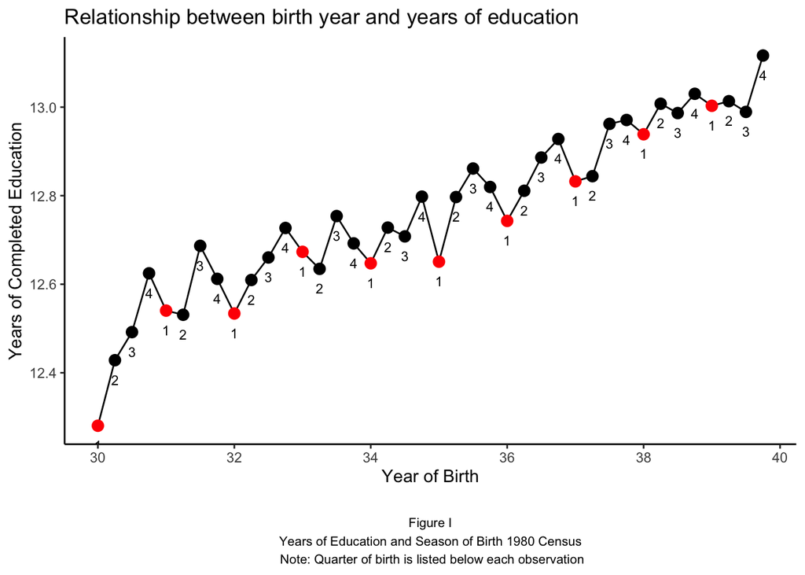

```r
data <- read_dta("data/AK91_1930_39.dta") %>%
  filter(YOB <= 39)

data$QOB <- as.factor(data$QOB)

data %>%
  group_by(YOB, QOB) %>%
  summarise(mean.EDUC = mean(EDUC),
            quarter.year = YOB + (as.numeric(QOB)/4) - 0.25) %>%
  ungroup() %>%
  unique() %>%
ggplot(aes(x = quarter.year, y = mean.EDUC)) +
  geom_path() +
  geom_point(aes(color=QOB), size = 3) +
  geom_text(aes(label = paste(QOB)),
          vjust = 2.5, size = 3) +
  scale_x_continuous(breaks = seq(30, 40, by = 2)) +
  scale_y_continuous(breaks = seq(12.2, 13.2, by = .2)) +
  scale_color_manual(values = c("red", "black", "black", "black")) +
  labs(x = "Year of Birth", y = "Years of Completed Education",
       title = "Relationship between birth year and years of education",
       caption = paste("Figure I\n",
       "Years of Education and Season of Birth 1980 Census \n",
       "Note: Quarter of birth is listed below each observation")) +
  theme_classic() +
  theme(plot.caption = element_text(
    color = "black",
    size = 8,
    lineheight = 1.2,
    hjust = 0.5,
    margin = margin(t = 20)),
    legend.position = "none")
```

15. Table I shows the relationship between quarter of birth and educational outcomes. Replicate the first row of Table I, i.e., find the coefficients of the first, second, and third quarter-of-birth dummies on total years of education. Your estimates do not need to be exactly the same as in the paper, but roughly of the same magnitude.

```r
data <- within(data, QOB <- relevel(QOB, ref = 4))

ols <- tidy(lm(formula = paste0('EDUC', " ~ QOB"), data = data))

table <- data.frame(
    `Outcome variable` = character(),
    `Birth cohort` = character(),
    Mean = double(),
    I = double(),
    II = double(),
    III = double(),
    `F-test` = character())

table <- rbind(table, data.frame(
    `Outcome variable` = 'Total years of Education',
    `Birth cohort` = '1930-1939',
    Mean = round(mean(data$EDUC, na.rm = TRUE), 3),
    I = paste(round(ols$estimate[2], 3),
              paste0('(',round(ols$std.error[2], 3)),')'),
    II = paste(round(ols$estimate[3], 3),
                paste0('(',round(ols$std.error[2], 3)),')'),
    III = paste(round(ols$estimate[4], 3),
                 paste0('(',round(ols$std.error[2], 3)), ')'),
    `F-test` = summary(lm(formula = paste0('EDUC', " ~ QOB"),
                          data = data))$fstat[[1]]))

kable(
    table,
    caption = "Quarter-of-birth effect",
    align = "c",
    col.names = c("Outcome Variable", "Birth Cohort",
                  "Mean", "I", "II", "III", "F-test")) %>%
  kable_styling(full_width = FALSE)
```

Quarter-of-birth effect

| Outcome Variable | Birth Cohort | Mean | I | II | III | F-test |
| --- | --- | --- | --- | --- | --- | --- |
| Total years of Education | 1930-1939 | 12.77 | -0.151 (0.016 ) | -0.095 (0.016 ) | -0.034 (0.016 ) | 34.00945 |

16. Create a reduced form table. In other words, you want to regress the log of weekly earnings on the quarter of birth dummies (our instrument). You may want to include year fixed effect.

```r
data$YOB <- as.factor(data$YOB)

reg.reduced.form <- felm(LWKLYWGE ~ QOB|0|0|0,data)
reg.reduced.form.fe <- felm(LWKLYWGE ~ QOB|YOB|0|0,data)

stargazer(reg.reduced.form, reg.reduced.form.fe, type = "html",
          column.labels = c("Reduced Form 1 (OLS)", "Reduced Form  2 (FE)"))
```

[output not shown]

17. Table III reports OLS and Wald estimates of returns of education. Replicate both estimates for men born 1930-1939 (Panel B).

```r
data$QOB_dummy <- ifelse(data$QOB == 1, 1, 0)

group1 <- data %>% filter(QOB == 1)
group2 <- data %>% filter(QOB != 1)

wage_1st <- mean(group1$LWKLYWGE)
se1 <- sd(group1$LWKLYWGE) / sqrt(nrow(group1))

wage_other <-  mean(group2$LWKLYWGE)
se2 <- sd(group2$LWKLYWGE) / sqrt(nrow(group2))

wage_diff <- wage_1st - wage_other
wage_err <- sqrt(se1^2 + se2^2)

educ_1st <- mean(group1$EDUC)
se1 <- sd(group1$EDUC) / sqrt(nrow(group1))

educ_other <- mean(group2$EDUC)
se2 <- sd(group2$EDUC) / sqrt(nrow(group2))

educ_diff <- educ_1st - educ_other
educ_err <- sqrt(se1^2 + se2^2)

# wald return to education
data$EDUC_pred <- lm(EDUC ~ QOB_dummy, data = data) %>% predict()
wald_rslt <- lm(LWKLYWGE ~ EDUC_pred, data = data)

# ols return to education
ols_rslt <- lm(LWKLYWGE ~ EDUC, data = data)

wald_est = coef(wald_rslt)["EDUC_pred"]
wald_err = sqrt(diag(vcovHC(wald_rslt, type = "HC1"))["EDUC_pred"])
ols_est = coef(ols_rslt)["EDUC"]
ols_err = sqrt(diag(vcovHC(ols_rslt, type = "HC1"))["EDUC"])

# create table
table <- data.frame(
    Variable = c("ln (wkly. wage)", "",
                 "Education", "",
                 "Wald est. of return to education", "",
                 "OLS return to education", ""),
    `(1) Born in 1st quarter of year` =
      c(round(wage_1st,5), "",
        round(educ_1st,5), "",
        "", "",
        "", ""),
    `(2) Born in 2nd, 3rd, or 4th quarter of year` =
      c(round(wage_other,5), "",
        round(educ_other,5), "",
        "", "",
        "", ""),
    `(3) Difference (std.error) (1) - (2)` =
      c(paste(round(wage_diff,5),
        paste0("(", round(wage_err ,5), ")")), "",
        paste(round(educ_diff,5),
        paste0("(", round(educ_err, 5), ")")), "",
        paste(round(wald_est[[1]], 5),
        paste0("(", round(wald_err[[1]], 5), ")")), "",
        paste(round(ols_est[[1]], 5),
        paste0("(", round(ols_err[[1]], 5), ")")), "")
  )

kable(
    table,
    caption =  "Panel B: Wald Estimates for 1980 Census - Men Born 1930-1939",
    align = "c",
    col.names = c("", "(1) Born in 1st quarter of year",
                  "(2) Born in 2nd, 3rd, or 4th quarter of year",
                  "(3) Difference (std.error) (1) - (2)")) %>%
  kable_styling(full_width = FALSE)
```

Panel B: Wald Estimates for 1980 Census - Men Born 1930-1939

1. Born in 1st quarter of year
2. Born in 2nd, 3rd, or 4th quarter of year
3. Difference (std.error) (1) - (2)

ln (wkly. wage)

5.8916

5.90269

-0.0111 (0.00274)

Education

12.68807

12.79688

-0.10882 (0.01332)

Wald est. of return to education

0.10199 (0.02522)

OLS return to education

0.07085 (0.00038)

18. Table V reports different specifications of the TSLS for men born 1930-1939. Run TSLS similar as in Column 2 and Column 6. First, instrument education with a set of quarter-of-birth x year-of-birth dummies, and add year fix effects as control. Why do we want to include year fix effects?

Second, similarly to Column 6, instrument education with the same interaction dummies, and add regional fix effects, year fix effects, race, married status, and an urban dummy.

```r
ivreg.2 <- ivreg(LWKLYWGE ~ EDUC + YOB | QOB*YOB, data = data)

ivreg.6 <- ivreg(LWKLYWGE ~ EDUC + YOB + NEWENG +
                   MIDATL + ENOCENT + WNOCENT +
                   SOATL + ESOCENT + WSOCENT + MT +
                   RACE + SMSA + MARRIED | QOB*YOB, data = data)


varnames <- c("EDUC", "RACE", "SMSA", "MARRIED")
labels <- c("Years of Education", "Race (1 == black)",
            "SMSA (1 == city center)", "Married (1 == married)")

birth_dummy <- c("Yes", "Yes")
region_dummy <- c("No", "Yes")

stargazer(ivreg.2, ivreg.6, type = "html",
          coef.names = labels,
          covariate.labels = labels,
          covariate.include = varnames,
          column.labels = c("Model 2 (TSLS)", "Model 6 (TSLS)"),
          add.lines = list(c("9 Year of Birth dummies", birth_dummy[1], birth_dummy[2]),
                           c("8 Region of Residence dummies",
                             region_dummy[1], region_dummy[2])),
                    omit = c("QOB", "YOB", "NEWENG", "MIDATL",
                             "ENOCENT", "WNOCENT", "SOATL", "ESOCENT",
                             "WSOCENT", "MT"))
```

|  | *Dependent variable:* |  |
| --- | --- | --- |
|  | LWKLYWGE |  |
|  | Model 2 (TSLS) | Model 6 (TSLS) |
|  | (1) | (2) |
| Years of Education | 0.089*** | 0.068*** |
|  | (0.016) | (0.024) |
| Race (1 == black) |  | -0.411 |
|  |  | (0.514) |
| SMSA (1 == city center) |  | -0.783* |
|  |  | (0.415) |
| Married (1 == married) |  | 0.486 |
|  |  | (0.522) |
| Constant | 4.793*** | 4.872*** |
|  | (0.201) | (0.821) |
| 9 Year of Birth dummies | Yes | Yes |
| 8 Region of Residence dummies | No | Yes |
| Observations | 329,509 | 329,509 |
| R<sup>2</sup> | 0.110 | -0.082 |
| Adjusted R<sup>2</sup> | 0.110 | -0.082 |
| Residual Std. Error | 0.640 (df = 329498) | 0.706 (df = 329487) |
| *Note:* | p<0.1; p<0.05; p<0.01 |  |

19. Now repeat the same exercise as the first 2LS2 in Question 18 (without additional controls, only year fix effects), but without using a built-in IV function – use only lm instead. Are your results the same as in the previous question?

```r
model_edu <- lm(EDUC ~ QOB*YOB, data = data)
data$educ_pred <- predict(model_edu)

model_lwklywge <- lm(LWKLYWGE ~ educ_pred + YOB, data = data)

stargazer(model_lwklywge, type = "html",
          column.labels = c("Model 2 (TSLS) Only Using `lm`"),
                    omit = c("QOB", "YOB"))
```

|  | *Dependent variable:* |
| --- | --- |
|  | LWKLYWGE |
|  | Model 2 (TSLS) Only Using `lm` |
| educ_pred | 0.089*** |
|  | (0.017) |
| Constant | 4.793*** |
|  | (0.213) |
| Observations | 329,509 |
| R<sup>2</sup> | 0.0001 |
| Adjusted R<sup>2</sup> | 0.0001 |
| Residual Std. Error | 0.679 (df = 329498) |
| F Statistic | 3.709*** (df = 10; 329498) |
| *Note:* | p<0.1; p<0.05; p<0.01 |

20. For the purpose of this question, define treatment as completing high school (12 or more years of education), and the instrument as binary, with Zi=1 if one is born in the fourth quarter, and 0 otherwise.

```r
data$treatment <- ifelse(data$EDUC >= 12, 1, 0)
data$QOB_dummy.4 <- ifelse(data$QOB == 4, 1, 0)
```

1. What is the share of the complier population?

```r
reg <- lm(treatment ~ QOB_dummy.4, data = data)

# Extract the LATE
late <- summary(reg)$coefficients[2]

# Calculate the share of compliers
print(late / mean(data$treatment))
```

```
## [1] 0.01849442
```

2. What is the average untreated outcome among the never-takers?

```r
mean(ifelse(data$treatment == 0 & data$QOB_dummy.4 == 0,
                  data$LWKLYWGE, NA), na.rm = TRUE)
```

```
## [1] 5.594505
```

3. What is the average treated outcome among the always-takers?

```r
mean(ifelse(data$treatment == 1 & data$QOB_dummy.4 == 1,
                  data$LWKLYWGE, NA), na.rm = TRUE)
```

```
## [1] 5.990925
```

4. Is there selection into treatment? State the assumptions necessary for your conclusion.

### IVs in Your Own Research

21. Think about a social relationship that would be best studied using an IV approach. Briefly state the research question and the main variables of interest in non-technical terms.

The research question could be “What is the effect of nurse staffing levels on patient outcomes in hospitals?” The main variables of interest would be the nurse staffing levels (nurse-to-patient ratios) and the patient outcomes (re-admission rates, length of hospital stay).

Because nurse staffing levels may be endogenous (i.e., they may be correlated with unobserved factors that affect patient outcomes), an instrumental variable approach could be used to estimate the causal effect of nurse staffing levels on patient outcomes. A plausible instrument for nurse staffing levels could be a state-mandated minimum nurse-to-patient ratio. This instrument could be used to estimate the causal effect of nurse staffing levels on patient outcomes by focusing on the population of patients who are most likely to be affected by nurse staffing levels (those who are admitted to hospitals with staffing levels near the state-mandated minimum).

22. Write out the empirical specification you would use and explain the equation.

$$\text{Outcome}_i = \alpha +
\beta\cdot\text{StaffingLevel}_i + \epsilon_i$$

$$\text{StaffingLevel}_i =
\gamma\cdot\text{MinimumRatio}_i + \delta_i$$

In this specification, $\text{Outcome}_i$ represents the patient outcome for patient $i$, $\text{StaffingLevel}_i$ represents the nurse staffing level for patient $i$, and $\text{MinimumRatio}_i$ represents the state-mandated minimum nurse-to-patient ratio for the hospital where patient $i$ is admitted. The coefficient $\beta$ represents the estimated effect of a one-unit increase in nurse staffing levels on patient outcomes, holding all other factors constant. The coefficient $\gamma$ represents the estimated effect of a one-unit increase in the state-mandated minimum ratio on nurse staffing levels, holding all other factors constant. The error terms $\epsilon_i$ and $\delta_i$ capture the unobserved factors that affect patient outcomes and nurse staffing levels, respectively.

To estimate the causal effect of nurse staffing levels on patient outcomes, an instrumental variable approach can be used where the first-stage regression of $\text{StaffingLevel}_i$ on $\text{MinimumRatio}_i$ is used to obtain predicted values of nurse staffing levels. The predicted values are then used as the instrumental variable in the second-stage regression of $\text{Outcome}_i$ on the predicted values of $\text{StaffingLevel}_i$.

23. If you clustered your standard errors or included fixed effects, explain why these methods reduced the likelihood of bias in your results (and if applicable, in which direction). If you did not, explain why these methods were not appropriate in your setting.